# Sports analytics in R

15 February 2018

[figure not shown]

## A general workflow for sports analytics

Determine the need through collaboration

Articulate the need as a question

Scope out the 'minimum viable product'

Allow time for peer review

Communicate the findings in appropriate ways

## Why use R for sports analytics?

### (or similar programming languages)

## Excel: The power and pitfalls of an 'all-in-one' tool

Data, analysis outputs, and visualisation are stored in one place

Data is easily manipulated - high risk of introducing errors

Point-and-click interface - manual repetition

Actions are not logged

Slow when working with large data sets or files storing many computations

Complex Excel workbooks can 'break' when shared with others

## The case for programming

Separation of data, analysis outputs, visualisations, and reports

Reproducible, transparent, and less error-prone workflow

Much faster for repetitive actions than point-and-click

Requires you to think early and often about data structure

Procedures are documented via scripts and command history

Build up a library of repeatable, adaptable procedures

## Now for some demos!

### But first…

## A quick intro to R

R is a statistical programming language, RStudio is an IDE for using R

Its most fundamental component is 'base R' but it is highly extensible

R is free and open source: users benefit from packages created by others

The R community is global and active - lots of help for when you get stuck!

Look for R workshops, conferences, and meetup groups, e.g., R Ladies

## Demo 1

### Summarising data from the Winter Olympics

Demo 1 uses the `winter` data set [downloadable from this link](https://www.kaggle.com/the-guardian/olympic-games/data).

It includes all podium results from Winter Olympic Games that have taken place from 1924 to 2014, inclusive.

[figure not shown]

## Import data

```r
# The readr package is efficient for reading (importing) of CSV files
library(readr)

# Read the data in
winter <- read_csv("winter.csv", col_names = TRUE, col_types = NULL)
```

## Check the data

```r
head(winter)
```

```
## # A tibble: 6 x 9
##    Year City     Sport    Discipline Athlete    Count~ Gend~ Event   Medal
##   <int> <chr>    <chr>    <chr>      <chr>      <chr>  <chr> <chr>   <chr>
## 1  1924 Chamonix Biathlon Biathlon   BERTHET, ~ FRA    Men   Milita~ Bron~
## 2  1924 Chamonix Biathlon Biathlon   MANDRILLO~ FRA    Men   Milita~ Bron~
## 3  1924 Chamonix Biathlon Biathlon   MANDRILLO~ FRA    Men   Milita~ Bron~
## 4  1924 Chamonix Biathlon Biathlon   "VANDELLE~ FRA    Men   Milita~ Bron~
## 5  1924 Chamonix Biathlon Biathlon   AUFDENBLA~ SUI    Men   Milita~ Gold
## 6  1924 Chamonix Biathlon Biathlon   JULEN, Al~ SUI    Men   Milita~ Gold
```

## Subset the data

Let's say we are interested in comparing the **number of gold medals won** by **Canada, Norway, and Sweden** from the **last five Winter Olympic Games**.

We need to subset the data to focus only on:

- Gold medal results
- Athletes from Canada (CAN), Norway (NOR), or Sweden (SWE), and
- Results from the last five Winter Olympics (1998 to 2014)

## Subset the data

```r
# The dplyr package includes useful data manipulation functions
library(dplyr)

# Subset the data
goldMedalComparison <- winter %>%
  filter(Medal == "Gold"
         & Country %in% c("CAN", "NOR", "SWE")
         & Year >= 1998)
```

## Check the data

```r
goldMedalComparison
```

```
## # A tibble: 358 x 9
##     Year City   Sport     Discipline  Athlete    Count~ Gend~ Event  Medal
##    <int> <chr>  <chr>     <chr>       <chr>      <chr>  <chr> <chr>  <chr>
##  1  1998 Nagano Biathlon  Biathlon    BJOERNDAL~ NOR    Men   10KM   Gold
##  2  1998 Nagano Biathlon  Biathlon    HANEVOLD,~ NOR    Men   20KM   Gold
##  3  1998 Nagano Bobsleigh Bobsleigh   LUEDERS, ~ CAN    Men   Two-M~ Gold
##  4  1998 Nagano Bobsleigh Bobsleigh   MACEACHER~ CAN    Men   Two-M~ Gold
##  5  1998 Nagano Curling   Curling     BETKER, J~ CAN    Women Curli~ Gold
##  6  1998 Nagano Curling   Curling     FORD, Ati~ CAN    Women Curli~ Gold
##  7  1998 Nagano Curling   Curling     GUDEREIT,~ CAN    Women Curli~ Gold
##  8  1998 Nagano Curling   Curling     MCCUSKER,~ CAN    Women Curli~ Gold
##  9  1998 Nagano Curling   Curling     SCHMIRLER~ CAN    Women Curli~ Gold
## 10  1998 Nagano Skating   Short Trac~ BEDARD, E~ CAN    Men   5000M~ Gold
## # ... with 348 more rows
```

## Wrangle the data

In the `winter` data set, the data is structured such that **one row is one medal-winning athlete**.

However…

- Team events (e.g., bobsleigh) comprise multiple athletes, and
- Within teams that achieve a podium finish, each athlete is awarded a medal.

For this analysis, we need to wrangle the data to get it into a format where **one row represents one gold medal per event** (rather than per athlete).

## Wrangle the data

```r
# Create a new variable to identify each unique event
goldMedalComparison$uniqueEventID <-
  paste(goldMedalComparison$Year, goldMedalComparison$Sport,
        goldMedalComparison$Discipline, goldMedalComparison$Country,
        goldMedalComparison$Gender, goldMedalComparison$Event, sep="_")
```

## Wrangle the data

```r
goldMedalComparison %>%
  select(uniqueEventID)
```

```
## # A tibble: 358 x 1
##    uniqueEventID
##    <chr>
##  1 1998_Biathlon_Biathlon_NOR_Men_10KM
##  2 1998_Biathlon_Biathlon_NOR_Men_20KM
##  3 1998_Bobsleigh_Bobsleigh_CAN_Men_Two-Man
##  4 1998_Bobsleigh_Bobsleigh_CAN_Men_Two-Man
##  5 1998_Curling_Curling_CAN_Women_Curling
##  6 1998_Curling_Curling_CAN_Women_Curling
##  7 1998_Curling_Curling_CAN_Women_Curling
##  8 1998_Curling_Curling_CAN_Women_Curling
##  9 1998_Curling_Curling_CAN_Women_Curling
## 10 1998_Skating_Short Track Speed Skating_CAN_Men_5000M Relay
## # ... with 348 more rows
```

## Wrangle the data

```r
# Identify duplicates
goldMedalComparison$duplicates <- duplicated(goldMedalComparison$uniqueEventID)

goldMedalComparison %>%
  select(uniqueEventID, duplicates)
```

```
## # A tibble: 358 x 2
##    uniqueEventID                                              duplicates
##    <chr>                                                      <lgl>
##  1 1998_Biathlon_Biathlon_NOR_Men_10KM                        F
##  2 1998_Biathlon_Biathlon_NOR_Men_20KM                        F
##  3 1998_Bobsleigh_Bobsleigh_CAN_Men_Two-Man                   F
##  4 1998_Bobsleigh_Bobsleigh_CAN_Men_Two-Man                   T
##  5 1998_Curling_Curling_CAN_Women_Curling                     F
##  6 1998_Curling_Curling_CAN_Women_Curling                     T
##  7 1998_Curling_Curling_CAN_Women_Curling                     T
##  8 1998_Curling_Curling_CAN_Women_Curling                     T
##  9 1998_Curling_Curling_CAN_Women_Curling                     T
## 10 1998_Skating_Short Track Speed Skating_CAN_Men_5000M Relay F
## # ... with 348 more rows
```

## Wrangle the data

```r
# Remove duplicates from the data
# and remove temporary variables used for identifying duplicates
goldMedalComparison <- goldMedalComparison %>%
  filter(duplicates == FALSE) %>%
  select(-uniqueEventID, -duplicates)
```

## Wrangle the data

```r
goldMedalComparison %>%
  select(Year, Sport, Country, Event)
```

```
## # A tibble: 105 x 4
##     Year Sport     Country Event
##    <int> <chr>     <chr>   <chr>
##  1  1998 Biathlon  NOR     10KM
##  2  1998 Biathlon  NOR     20KM
##  3  1998 Bobsleigh CAN     Two-Man
##  4  1998 Curling   CAN     Curling
##  5  1998 Skating   CAN     5000M Relay
##  6  1998 Skating   CAN     500M
##  7  1998 Skating   NOR     1500M
##  8  1998 Skating   CAN     500M
##  9  1998 Skiing    NOR     Slalom
## 10  1998 Skiing    NOR     10KM Pursuit
## # ... with 95 more rows
```

## Calculate summary statistics

The data is now in a format that is ready for calculating summary statistics.

For instance, we can tabulate the total number of gold medals won by Canada, Norway, and Sweden at each of the Winter Games since 1998.

## Calculate summary statistics

```r
# The reshape2 package is useful for manipulating data
# from long-to-wide format and vice versa
library(reshape2)

# Calculate total number of gold medals per team per Winter Games
goldMedalTotals <- goldMedalComparison %>%
  group_by(Year, City, Country) %>%
  summarise(goldMedalTotal = length(Medal)) %>%
  ungroup()

# Reshape the data from long-to-wide format for tabulating
goldMedalTotalsWide <- dcast(goldMedalTotals,
                             Year + City ~ Country,
                             value.var = "goldMedalTotal")
```

## Calculate summary statistics

```r
# Check the reshaped data
goldMedalTotalsWide
```

```
##   Year           City CAN NOR SWE
## 1 1998         Nagano   6  10  NA
## 2 2002 Salt Lake City   8  12  NA
## 3 2006          Turin   7   2   7
## 4 2010      Vancouver  15   9   5
## 5 2014          Sochi  10  12   2
```

```r
# NAs appear in the data because Sweden did not win any gold medals
# at the 1998 and 2002 Winter Games

# Replace these NAs with zeroes
goldMedalTotalsWide$SWE[is.na(goldMedalTotalsWide$SWE)] <- 0
```

## Calculate summary statistics

```r
# The DT package is used to display interactive tables in HTML documents
library(DT)

# Display the table
datatable(goldMedalTotalsWide, options = list(dom = 't'), rownames = FALSE)
```

| Year | City | CAN | NOR | SWE |
| --- | --- | --- | --- | --- |
| 1998 | Nagano | 6 | 10 | 0 |
| 2002 | Salt Lake City | 8 | 12 | 0 |
| 2006 | Turin | 7 | 2 | 7 |
| 2010 | Vancouver | 15 | 9 | 5 |
| 2014 | Sochi | 10 | 12 | 2 |

## Calculate summary statistics

We can use the data frame we've just created - gold medal totals per team per Games - to calculate the median number of gold medals won by Canada, Norway, and Sweden at the last five Games.

```r
goldMedalMedians <- goldMedalTotalsWide %>%
  summarise(CAN = median(CAN),
            NOR = median(NOR),
            SWE = median(SWE))

goldMedalMedians
```

```
##   CAN NOR SWE
## 1   8  10   2
```

## Demo 2

### Visualising tennis data

## Import the data

We will use data from the ATP and WTA tennis tours to show how sports data can be visualised using R.

```r
# The deuce package performs web scraping to obtain up-to-date data
# from tennis matches played on the ATP and WTA tours
library(deuce)

# Load up the data from ATP and WTA tours
data(atp_matches)
data(wta_matches)
```

## Subset the data

Let's investigate data from the Australian Open, from 2008 to 2017. We need to subset the data first.

```r
ausOpenATP <- atp_matches %>%
  filter(tourney_name == "Australian Open" & year >= 2008)

ausOpenWTA <- wta_matches %>%
  filter(tourney_name == "Australian Open" & year >= 2008)
```

## Plot the data

Let's try plotting the age of men's match winners across each year.

```r
# The ggplot2 package is widely used for plotting in R
# It uses a layer-by-layer approach to building plots
library(ggplot2)

# Build the plot
p <- ggplot(ausOpenATP, aes(x = factor(year), y = winner_age, fill = winner_age))
p <- p + geom_boxplot(aes(group = cut_width(year, 0.25)),
                      fill = "white",
                      colour = "#3366FF",
                      outlier.alpha = 0.5,
                      outlier.size = 2)
p <- p + labs(title = "Age of men's match winners - Australian Open, 2008-2017",
              x = "Year",
              y = "Age of winner")
ausOpenATP_winner_age <- p
```

## Plot the data

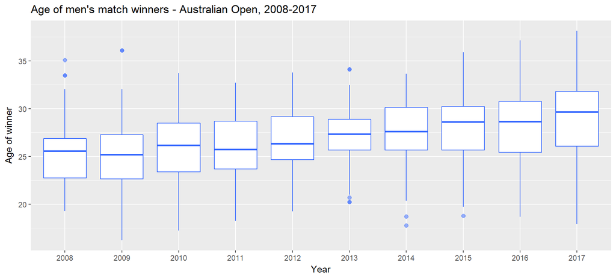

## A small sample of other cool things you can do in R

## Statistical analyses

- NHST: t tests, ANOVAs, correlation, linear / logistic regression
- MBI? Effect sizes
- Linear and generalised linear mixed models
- Multivariate statistics
- Classification models, e.g., decision trees
- Network analysis
- Time series decomposition and forecasting
- Much much more…

## Geospatial plots

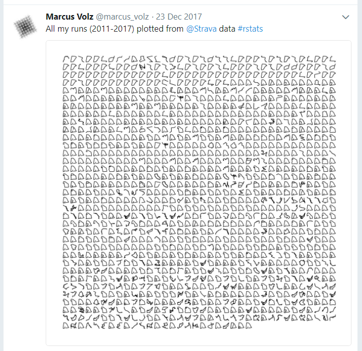

## Create your own coding blog

[figure not shown]

Dr Jacquie Tran | @jacquietran | https://www.jacquietran.com

## Appendix 1: Learning R

## Starter resources

[Try R](http://tryr.codeschool.com): An in-the-browser tutorial for getting to know the R language - no software installation needed.

'Introduction to R': Free course on [Data Camp](https://www.datacamp.com).

['R for Data Science'](http://r4ds.had.co.nz/), by Garrett Grolemund & Hadley Wickham.

['Data wrangling, exploration, and analysis with R'](http://stat545.com/): Course materials from a unit taught at the University of British Columbia by Prof Jenny Bryan.

['R for data analysis and visualisation'](http://www.datacarpentry.org/R-ecology-lesson/index.html): Data Carpentry lesson using ecology data

[The Data Science Guide](http://www.datasciguide.com/find-content-2/): A useful resource for finding content all over the web for learning different data science skills and programming languages. You can tailor your search to your current level of expertise in a given domain.

## Transitioning from Excel to R

['R for Excel Users'](http://blog.shotwell.ca/2017/02/02/r-for-excel-users/): Blog post by Gordon Shotwell

['Introduction to R for Excel Users'](https://tomhopper.me/2016/05/03/r-for-excel-users/): Free ebook by Tom Hopper

## Appendix 2: The R community

## The R community

Follow the [#rstats hashtag on Twitter](https://twitter.com/search?q=%23rstats&src=typd)

Many prominent R users and developers have blogs and / or tweet regularly. Here are some of my favourites:

- @JennyBryan
- @ma_salmon
- @alice_data
- @dataandme
- @visnut
- @kierisi
- @thomasp85
- @xieyihui
- @drob
- @juliasilge

Join, read, and contribute to the R Studio Community discussions: https://community.rstudio.com/

You can discover lots of weird, wonderful, and useful R packages and repositories on Github: https://github.com/trending/r

## Appendix 3: Sports data sets

## 'Ready to analyse'

[AFLW data](https://github.com/ropenscilabs/ozwomensport/tree/master/AFLW) stored on Github

[ATP and WTA tennis data](https://github.com/skoval/deuce), accessible via the R package `deuce`

[Olympic Sports and Medals, 1896-2014](https://www.kaggle.com/the-guardian/olympic-games/data) collated by The Guardian

[NBA, NFL, MLB, and soccer data](https://github.com/fivethirtyeight/data) from [FiveThirtyEight](https://fivethirtyeight.com)

[NFL play-by-play data](https://github.com/maksimhorowitz/nflscrapR), accessible via the R package `nflscrapR`

MLB data from [Lahman's Baseball Database](http://seanlahman.com/baseball-archive/statistics/)

[Cricket data](https://github.com/ropenscilabs/cricinfo), accessible via the R package `cricinfo`

## Needs scraping / cleaning

[WNBA player and game data](http://www.wnba.com/stats/) from WNBA.com

AFL match statistics from [AFL Tables](https://afltables.com/afl/afl_index.html)

AFL draft and trade data from [Draft Guru](https://www.draftguru.com.au/)

[NCAA men's college basketball data](https://www.sports-reference.com/cbb/) from [Sports Reference](https://www.sports-reference.com)

[NCAA men's college football data](https://www.sports-reference.com/cfb/) from [Sports Reference](https://www.sports-reference.com)

## Other references and resources

## References and resources

[Introduction to dplyr](http://stat545.com/block009_dplyr-intro.html) [An introduction to reshape2](http://seananderson.ca/2013/10/19/reshape.html)